# Deep Learning- 課程 28－Deep Learning- An introduction to R-CNN & Fast & Faster R-CNN - Python Tutorial

[figure not shown]

...

[figure not shown]

- R-CNN - Paper 論文參考
  - https://arxiv.org/abs/1311.2524
- Fast R-CNN - Paper 論文參考
  - https://arxiv.org/abs/1504.08083
- Faster R-CNN - Paper 論文參考
  - https://arxiv.org/abs/1506.01497
- One-Stage Object Detection Quick View
- Two-Stage Object Detection Quick View

[figure not shown]

- R-CNN 系列 - 模型摘要
  - R-CNN Family

[figure not shown]

# RCNN

- R-CNN Quick Rivew - 作者 Ross Girshick
  - Rich feature hierarchies for accurate object detection and semantic segmentation

[figure not shown]

- R-CNN 的 概念步驟
  - 1 圖像作為輸入
  - 2 圖像被傳遞到ConvNet，ConvNet依次生成關注區域
  - 3 RoI池化層應用於所有這些區域，以根據ConvNet的輸入對它們進行整形
  - 4 然後，每個區域都傳遞到完全連接的網絡。
  - 5 完全連接的網絡之上使用softmax層來輸出類
  - 6 與softmax層一起，線性回歸層也可以並行使用
    - 以輸出預測類的邊界框坐標

[figure not shown]

- 圖像輸入

[figure not shown]

- 圖像被傳遞到 ConvNet
  - ConvNet 相應地 返回 ROI 感興趣的區域

[figure not shown]

- 提取的 ROI 感興趣區域上 - 應用 RoI 池化層 Pooling Layer
  - 以確保所有區域的大小相同

[figure not shown]

- 將這些區域傳遞到對它們進行分類的完全連接的網絡
  - 同時使用 Softmax 和 線性回歸層 - 返回邊界框

[figure not shown]

R-CNN 物體檢測 - Object Detection

```
- 速度很慢
    - R-CNN 一開始必須先產生約 2000 個區域
    - 每個區域都要 - 丟進 CNN 中 - 擷取特徵
      - 至少 2000 次的 - CNN

- 難以訓練
    - Model  - 分開成三部份
        - CNN 取出特徵的 - CNN
        - SVM 分類的 SVM
        - Bounding Box 優化 - 的線性回歸。
    - R-CNN 不容易作訓練

- 儲存容量存 - 需求
    - 保存 - 每個區域建議 - 每個特徵圖
           - 需要大量的內存 - 儲存容量
```

- R-CNN 系統 - R-CNN System

[figure not shown]

- RCNN 問題
  - 訓練 RCNN模型 - 緩慢
- 據選擇性搜索 為每個圖像提取 2,000個區域
- 使用CNN提取每個圖像區域的特徵
  - 假設 有 N張圖像
    - CNN 特徵的數量
      - N * 2,000
- RCNN 進行對象檢測的整個過程
  - 有三個模型
    - 1. CNN 用於 - 特徵提取
    - 1. 用於 識別對象的 - 線性 SVM分類器
    - 1. 用於 邊界框的 - 回歸模型
- Backbone Network - VGG16

[figure not shown]

# Fast RCNN

- Fast RCNN 解決了 RCNN的兩個主要問題
  - 將每個圖像傳遞一個 - 而不是 2,000個 區域到 ConvNet
  - 使用一個替代三個不同的模型
    - 來 提取特徵，分類 和 生成邊界框
- Fast RCNN 的 概念步驟
  - 1 圖像 作為輸入
  - 2 圖像 傳遞到ConvNet，ConvNet依次生成 ROI 關注區域
  - 3 RoI Pooling Layer池化層
    - 應用於所有這些區域
    - 根據 ConvNet的輸入 進行整形
    - 然後，每個區域都傳遞到 FC 完全連接的網絡
  - 4 FC 完全連接的網絡之上
    - 使用 softmax層 來輸出類 Classes
    - 與 Softmax層一起，
      - 線性回歸層 Linear Regression Layer 並行使用
        - 輸出預測類 Predicted Classes
        - 的邊界框坐標 Bounding Box Coordinates
- 圖像輸入

[figure not shown]

- 圖像被傳遞到 ConvNet
  - ConvNet 相應地 返回 ROI 感興趣的區域

[figure not shown]

- 在提取的感興趣區域上 -應用 RoI Pooling Layer 池化層
  - 確保所有區域的大小相同

[figure not shown]

- 將這些區域傳遞到對它們進行分類的完全連接的網絡
  - 同時使用 Softmax 和 線性回歸層 - 返回邊界框

[figure not shown]

- 與 RCNN中 的三個不同模型不同
- Fast RCNN 使用單個模型
  - 從區域中提取特徵
    - 將特徵劃分為不同的類別
    - 並同時返回所標識類別的邊界框
- Fast R-CNN Quick Rivew
- Fast R-CNN 系統 - System
  - Fast R-CNN 解決 R-CNN運算效能 - 優化的演算法
    - R-CNN 計算 2000個 - Region proposal
    - 放入 CNN
      - 需要 個別運算 -很多重複的區域
    - Fast R-CNN
      - 只運算 一次 CNN
      - CNN 擷取出來 的特徵
        - 2000 個Region proposal
        - 做運用
      - 利用 RoIpooling (Region of Interest Pooling)
        - 取出的 Region
        - 對應到 Feature map 輸出後
          - 各自
            - - 接上 FC 去做 - Softmax分類 - bbox Regressor

[figure not shown]

- Fast RCNN 存在某些問題
  - 還使用選擇性搜索 - Selective Search
    - 作為建議方法來找到感興趣的區域
    - 這是一個緩慢且耗時的過程
  - 每個圖像 大約需要 2秒鐘 才能檢測到對象

# Faster RCNN

- Faster RCNN - Fast RCNN的 修改版本
  - 主要區別在於
  - Fast RCNN - 使用 " 選擇性搜索 Selective Search " 稱為 SS 來生成感興趣區域
  - Faster RCNN - 使用 " 區域提議網絡 Region Proposal Network " 稱為 RPN 來生成感興趣區域
    - RPN 將圖像特徵圖作為輸入
      - 並生成一組對象建議
      - 每個對象建議 Objectness Score 都帶有一個客觀評分作為輸出
- Faster RCNN 的 概念步驟
  - 1 圖像 作為輸入
  - 2 圖像 傳遞到ConvNet，ConvNet依次生成 ROI 關注區域
  - 3 區域提議網絡 RPN 應用於這些特徵圖
    - 將返回目標提議及其目標 Score
  - 4 RoI池層 應用於這些提議
    - 以將所有提議縮減為相同大小
    - 傳遞到一個完全連接的層 FC
    - 使用 Softmax層 and Linear Regression Layer 層
      - 來輸出類 Classes
        - 輸出預測類 Predicted Classes
        - 邊界框坐標 Bounding Box Coordinates

[figure not shown]

- 區域提案網絡 Region Proposal Network (RPN) - 工作原理
  - Faster RCNN 從CNN獲取特徵圖
  - 將傳遞到 地區提議網絡
  - RPN 在這些特徵圖上使用一個滑動窗口
    - 並且在每個窗口上
      - 會生成k個形狀 和大小不同的錨框 Anchor

[figure not shown]

- 錨框 Anchor 是固定大小的邊界框
  - 位於整個圖像中，並且具有不同的形狀和大小
  - 對於每個錨點
- RPN 預測兩件事
  - 1.首先是錨點是對象的概率
    - 不考慮對象所屬的類
  - 2.BBR 回歸器 Bounding Box Regressor
    - 用於調整錨點 - 以更好地適應對象
- 將具有不同形狀和大小的邊界框
  - 傳遞給 RoI Layer 池層
  - 在RPN步驟之後，可能會有沒有為其分配類別的投標
  - 可以採用每個建議並對其進行裁剪
  - 以便每個建議都包含一個對象
    - RoI池層
  - 為每個錨點提取大小固定的特徵圖
- 然後將這些特徵圖傳
  - 遞到 Softmax 和 線性回歸層的完全連接層 FC
  - 對對象進行分類
    - 並預測所標識對象的邊界框

[figure not shown]

- Faster RCNN 存在某些問題
- 所有對象檢演算法
  - 都使用區域來識別對象
  - 網絡不會一次性查看完整的圖像，而是順序關注圖像的各個部分
- 這帶來了兩個並發症：
  - 該演算法需要多次通過單個圖像來提取所有對象
  - 由於存在著一個接一個地工作的不同系統
    - 因此系統的性能
    - 進一步取決於之前的系統如何執行

[figure not shown]

# 程式範例

- 忽略 警告訊息 Warning Message

```python
import warnings
warnings.filterwarnings("ignore")
```

- 檢查是否 - 有 GPU

```python
from tensorflow.python.client import device_lib
print (device_lib.list_local_devices())
```

```
[name: "/device:CPU:0"
device_type: "CPU"
memory_limit: 268435456
locality {
}
incarnation: 12585129402891084200
, name: "/device:GPU:0"
device_type: "GPU"
memory_limit: 3176441446
locality {
  bus_id: 1
  links {
  }
}
incarnation: 11881963091109522943
physical_device_desc: "device: 0, name: GeForce GTX 980M, pci bus id: 0000:01:00.0, compute capability: 5.2"
]
```

- os.environ 在 Jupyter Notebok 中 - 設置環境變量
- 初始化TensorFlow
  - 將 TensorFlow 限制為第一個GPU之前

```python
import os
os.environ["CUDA_DEVICE_ORDER"]="PCI_BUS_ID"
os.environ["CUDA_VISIBLE_DEVICES"]="0"
```

- Checking Python / Keras 版本

```python
!python -V
```

```
Python 3.6.7
```

```python
import keras
print(keras.__version__)
```

```
2.2.4
```

- 安裝 / 導入
  - Install/ Import 所需的庫 - required libraries
- Ploting Relative Module

```python
%matplotlib inline
import matplotlib.pyplot as plt
from matplotlib import patches
import pandas as pd
```

- Custom Module

```python
ddir
```

```
 磁碟區 C 中的磁碟是 OS
 磁碟區序號:  68E3-32FD

 C:\Users\calvi\OneDrive\桌面\AD課程28\BCCD_Dataset\BCCD_Dataset 的目錄

2020/02/05  上午 11:53    <DIR>          .
2020/02/05  上午 11:53    <DIR>          ..
2020/02/03  上午 10:06    <DIR>          .ipynb_checkpoints
2020/01/23  上午 10:16    <DIR>          BCCD
2020/01/23  上午 10:16    <DIR>          dataset
2020/01/23  上午 10:16    <DIR>          imagesBox
2020/02/05  上午 11:24    <DIR>          scripts
               0 個檔案               0 位元組
               7 個目錄  10,602,123,264 位元組可用
```

```python
cd ..
```

```python
ls
```

```
 磁碟區 C 中的磁碟是 OS
 磁碟區序號:  68E3-32FD

 C:\Users\calvi\OneDrive\桌面\AD課程28\BCCD_Dataset\BCCD_Dataset 的目錄

2020/02/05  上午 11:53    <DIR>          .
2020/02/05  上午 11:53    <DIR>          ..
2019/11/21  上午 08:54                12 .gitignore
2020/02/03  上午 10:06    <DIR>          .ipynb_checkpoints
2020/01/20  下午 05:53         7,823,429 all_CELL_data-master.zip
2020/01/23  上午 10:16    <DIR>          BCCD
2020/01/20  上午 09:56         7,448,382 BCCD_Dataset-1.0.tar.gz
2020/01/20  上午 09:55         7,875,205 BCCD_Dataset-1.0.zip
2020/01/20  上午 09:55        13,334,435 bccd_rec.zip
2020/01/23  上午 11:46            66,311 BCCD1.jpg
2019/11/21  上午 08:54             4,791 BloodImage_00000.xml
2020/01/23  上午 10:16    <DIR>          dataset
2020/01/20  下午 05:52         7,814,312 dataset-master.zip
2019/11/21  上午 08:54            66,311 example.jpg
2019/11/21  上午 08:54             1,783 export.py
2020/01/23  上午 10:16    <DIR>          imagesBox
2019/11/21  上午 08:54             1,065 LICENSE
2020/02/05  上午 11:39           242,793 mike.csv
2019/11/21  上午 08:54             3,530 plot.py
2020/01/20  下午 01:43                49 raccoon_labels.csv
2019/11/21  上午 08:54             3,129 README.md
2020/02/05  上午 11:24    <DIR>          scripts
2020/02/05  上午 11:39           203,680 test.csv
2019/03/04  上午 11:52             1,140 WinRAR.lnk
2020/02/05  上午 11:53           594,246 課程 28－Deep Learning- An introduction to  R-CNN & Fast & Faster R-CNN.ipynb
              18 個檔案      45,484,603 位元組
               7 個目錄  10,288,787,456 位元組可用
```

# BCCD_Dataset/export.py xml to csv

```python
import os
import glob
import pandas as pd
import xml.etree.ElementTree as ET


def xml_to_csv(path):
    xml_list = []
    for xml_file in glob.glob(path + '/*.xml'):
        tree = ET.parse(xml_file)
        root = tree.getroot()
        for member in root.findall('object'):
            value = (root.find('filename').text,
                     int(root.find('size')[0].text),
                     int(root.find('size')[1].text),
                     member[0].text,
                     int(member[4][0].text),
                     int(member[4][1].text),
                     int(member[4][2].text),
                     int(member[4][3].text)
                     )
            xml_list.append(value)
    column_name = ['filename', 'width', 'height', 'class', 'xmin', 'ymin', 'xmax', 'ymax']
    xml_df = pd.DataFrame(xml_list, columns=column_name)
    return xml_df


def main():
    image_path = os.path.join(os.getcwd(), 'BCCD/annotations')
    xml_df = xml_to_csv(image_path)
    xml_df.to_csv('mike.csv', index=None)
    print('Successfully converted xml to csv as mike.csv .')


# pandas - read_csv 讀取 mike.csv file 文件

main()

train = pd.read_csv('mike.csv')
train.head()
```

```
Successfully converted xml to csv as mike.csv .
```

|  | filename | width | height | class | xmin | ymin | xmax | ymax |
| --- | --- | --- | --- | --- | --- | --- | --- | --- |
| 0 | BloodImage_00000.jpg | 640 | 480 | WBC | 260 | 177 | 491 | 376 |
| 1 | BloodImage_00000.jpg | 640 | 480 | RBC | 78 | 336 | 184 | 435 |
| 2 | BloodImage_00000.jpg | 640 | 480 | RBC | 63 | 237 | 169 | 336 |
| 3 | BloodImage_00000.jpg | 640 | 480 | RBC | 214 | 362 | 320 | 461 |
| 4 | BloodImage_00000.jpg | 640 | 480 | RBC | 414 | 352 | 506 | 445 |

```python
import os, sys, random
import xml.etree.ElementTree as ET
from glob import glob
import pandas as pd
from shutil import copyfile

annotations = glob('BCCD/Annotations/*.xml')

df = []
cnt = 0
for file in annotations:
    #filename = file.split('/')[-1].split('.')[0] + '.jpg'
    #filename = str(cnt) + '.jpg'
    filename = file.split('\\')[-1]
    filename =filename.split('.')[0] + '.jpg'
    row = []
    parsedXML = ET.parse(file)
    for node in parsedXML.getroot().iter('object'):
        blood_cells = node.find('name').text
        xmin = int(node.find('bndbox/xmin').text)
        xmax = int(node.find('bndbox/xmax').text)
        ymin = int(node.find('bndbox/ymin').text)
        ymax = int(node.find('bndbox/ymax').text)

        row = [filename, blood_cells, xmin, xmax, ymin, ymax]
        df.append(row)
        cnt += 1

data = pd.DataFrame(df, columns=['filename', 'cell_type', 'xmin', 'xmax', 'ymin', 'ymax'])

data[['filename', 'cell_type', 'xmin', 'xmax', 'ymin', 'ymax']].to_csv('test.csv', index=False)

print(" Converting Xml to CSV as test.csv  file is done ")


# pandas - read_csv 讀取 mike.csv file 文件

train = pd.read_csv('test.csv')
train.head()
```

```
 Converting Xml to CSV as test.csv  file is done
```

|  | filename | cell_type | xmin | xmax | ymin | ymax |
| --- | --- | --- | --- | --- | --- | --- |
| 0 | BloodImage_00000.jpg | WBC | 260 | 491 | 177 | 376 |
| 1 | BloodImage_00000.jpg | RBC | 78 | 184 | 336 | 435 |
| 2 | BloodImage_00000.jpg | RBC | 63 | 169 | 237 | 336 |
| 3 | BloodImage_00000.jpg | RBC | 214 | 320 | 362 | 461 |
| 4 | BloodImage_00000.jpg | RBC | 414 | 506 | 352 | 445 |

```python
train = pd.read_csv('mike.csv')
train.head()
```

|  | filename | width | height | class | xmin | ymin | xmax | ymax |
| --- | --- | --- | --- | --- | --- | --- | --- | --- |
| 0 | BloodImage_00000.jpg | 640 | 480 | WBC | 260 | 177 | 491 | 376 |
| 1 | BloodImage_00000.jpg | 640 | 480 | RBC | 78 | 336 | 184 | 435 |
| 2 | BloodImage_00000.jpg | 640 | 480 | RBC | 63 | 237 | 169 | 336 |
| 3 | BloodImage_00000.jpg | 640 | 480 | RBC | 214 | 362 | 320 | 461 |
| 4 | BloodImage_00000.jpg | 640 | 480 | RBC | 414 | 352 | 506 | 445 |

# checking test.csv file whether is suitable for us

```python
# read the csv file using read_csv function of pandas
#train = pd.read_csv('test.csv')

train = pd.read_csv('test.csv')
train.head()
```

|  | filename | cell_type | xmin | xmax | ymin | ymax |
| --- | --- | --- | --- | --- | --- | --- |
| 0 | BloodImage_00000.jpg | WBC | 260 | 491 | 177 | 376 |
| 1 | BloodImage_00000.jpg | RBC | 78 | 184 | 336 | 435 |
| 2 | BloodImage_00000.jpg | RBC | 63 | 169 | 237 | 336 |
| 3 | BloodImage_00000.jpg | RBC | 214 | 320 | 362 | 461 |
| 4 | BloodImage_00000.jpg | RBC | 414 | 506 | 352 | 445 |

# Columns rename

```python
train.rename(columns= {"cell_type" : " mike_type" })
```

|  | filename | mike_type | xmin | xmax | ymin | ymax |
| --- | --- | --- | --- | --- | --- | --- |
| 0 | BloodImage_00000.jpg | WBC | 260 | 491 | 177 | 376 |
| 1 | BloodImage_00000.jpg | RBC | 78 | 184 | 336 | 435 |
| 2 | BloodImage_00000.jpg | RBC | 63 | 169 | 237 | 336 |
| 3 | BloodImage_00000.jpg | RBC | 214 | 320 | 362 | 461 |
| 4 | BloodImage_00000.jpg | RBC | 414 | 506 | 352 | 445 |
| ... | ... | ... | ... | ... | ... | ... |
| 4883 | BloodImage_00410.jpg | Platelets | 239 | 291 | 275 | 321 |
| 4884 | BloodImage_00410.jpg | Platelets | 121 | 189 | 260 | 320 |
| 4885 | BloodImage_00410.jpg | Platelets | 57 | 104 | 119 | 167 |
| 4886 | BloodImage_00410.jpg | Platelets | 1 | 29 | 286 | 327 |
| 4887 | BloodImage_00410.jpg | WBC | 367 | 611 | 166 | 394 |

4888 rows × 6 columns

```python
train.rename(columns= {"mike_type" : "cell_type" })
```

|  | filename | cell_type | xmin | xmax | ymin | ymax |
| --- | --- | --- | --- | --- | --- | --- |
| 0 | BloodImage_00000.jpg | WBC | 260 | 491 | 177 | 376 |
| 1 | BloodImage_00000.jpg | RBC | 78 | 184 | 336 | 435 |
| 2 | BloodImage_00000.jpg | RBC | 63 | 169 | 237 | 336 |
| 3 | BloodImage_00000.jpg | RBC | 214 | 320 | 362 | 461 |
| 4 | BloodImage_00000.jpg | RBC | 414 | 506 | 352 | 445 |
| ... | ... | ... | ... | ... | ... | ... |
| 4883 | BloodImage_00410.jpg | Platelets | 239 | 291 | 275 | 321 |
| 4884 | BloodImage_00410.jpg | Platelets | 121 | 189 | 260 | 320 |
| 4885 | BloodImage_00410.jpg | Platelets | 57 | 104 | 119 | 167 |
| 4886 | BloodImage_00410.jpg | Platelets | 1 | 29 | 286 | 327 |
| 4887 | BloodImage_00410.jpg | WBC | 367 | 611 | 166 | 394 |

4888 rows × 6 columns

- 再次檢查 返回原始 test.csv文件 - Checking it again after Back to Orginal test.csv file

```python
train = pd.read_csv('test.csv')
train.head()
```

|  | filename | cell_type | xmin | xmax | ymin | ymax |
| --- | --- | --- | --- | --- | --- | --- |
| 0 | BloodImage_00000.jpg | WBC | 260 | 491 | 177 | 376 |
| 1 | BloodImage_00000.jpg | RBC | 78 | 184 | 336 | 435 |
| 2 | BloodImage_00000.jpg | RBC | 63 | 169 | 237 | 336 |
| 3 | BloodImage_00000.jpg | RBC | 214 | 320 | 362 | 461 |
| 4 | BloodImage_00000.jpg | RBC | 414 | 506 | 352 | 445 |

```python
train.tail()
```

|  | filename | cell_type | xmin | xmax | ymin | ymax |
| --- | --- | --- | --- | --- | --- | --- |
| 4883 | BloodImage_00410.jpg | Platelets | 239 | 291 | 275 | 321 |
| 4884 | BloodImage_00410.jpg | Platelets | 121 | 189 | 260 | 320 |
| 4885 | BloodImage_00410.jpg | Platelets | 57 | 104 | 119 | 167 |
| 4886 | BloodImage_00410.jpg | Platelets | 1 | 29 | 286 | 327 |
| 4887 | BloodImage_00410.jpg | WBC | 367 | 611 | 166 | 394 |

- 計算 訓練 集 數 - Number of unique training images

```python
train['filename'].nunique()
```

```
364
```

- 計算 訓練 集 類別 - Number of classes

```python
train['cell_type'].value_counts()
```

```
RBC          4155
WBC           372
Platelets     361
Name: cell_type, dtype: int64
```

# 紅血球細胞 (RBC) ，白血球細胞 (WBC) 白細胞 和 血小板細胞 (Platelets)

- 視覺化 Visualization

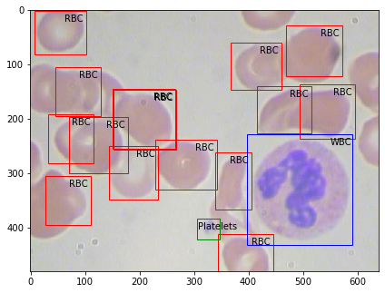

```python
fig = plt.figure()

# 圖像 上添加 軸添 -  add axes to the image
ax = fig.add_axes([0,0,1,1])

# 導入圖像 並繪製圖像 - read and plot the image

image = plt.imread('BCCD/JPEGImages/BloodImage_00100.jpg')
plt.imshow(image)

# 讀入圖像中  不同的對象 - iterating over the image for different objects
# for _,row in train[train.image_names == "BloodImage_00100.jpg"].iterrows():

for _,row in train[train.filename == "BloodImage_00100.jpg"].iterrows():
    xmin = row.xmin
    xmax = row.xmax
    ymin = row.ymin
    ymax = row.ymax

    width = xmax - xmin
    height = ymax - ymin

    # 不同類別的對象 分配不同的顏色 - classes of objects
    if row.cell_type == 'RBC':
        edgecolor = 'r'
        ax.annotate('RBC', xy=(xmax-40,ymin+20))
    elif row.cell_type == 'WBC':
        edgecolor = 'b'
        ax.annotate('WBC', xy=(xmax-40,ymin+20))
    elif row.cell_type == 'Platelets':
        edgecolor = 'g'
        ax.annotate('Platelets', xy=(xmax-40,ymin+20))

    # 圖像中 添加 邊框 - add bounding boxes to the image
    rect = patches.Rectangle((xmin,ymin), width, height, edgecolor = edgecolor, facecolor = 'none')

    ax.add_patch(rect)
```

# 顯示原始照片- BloodImage_00000.jpg

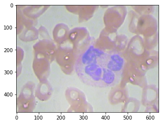

```python
image = plt.imread('BCCD/JPEGImages/BloodImage_00000.jpg')
plt.imshow(image)
```

# plot.py: it plots the boxes for each image and save it in a new directory.

```python
%%time

######################################################################################
### Author/Developer: Nicolas CHEN
### Filename: plotBox.py
### Version: 1.0
### Field of research: Deep Learning in medical imaging
### Purpose: This Python script plots the boxes for each image from the dataset
### Output: This Python script plots the boxes for each image and save it in
### a new directory

######################################################################################
### HISTORY
### Version | Date          | Author       | Evolution
### 1.0     | 17/11/2018    | Nicolas CHEN | Initial version
######################################################################################

# importing required libraries
import pandas as pd
import matplotlib.pyplot as plt
from matplotlib import patches
import os

def filterFiles(directoryPath, extension):
    """
        This function filters the format files with the selected extension in the directory

        Args:
            directoryPath (str): relative path of the directory that contains text files
            extension (str): extension file
        Returns:
            The list of filtered files with the selected extension
    """
    relevant_path = directoryPath
    included_extensions = [extension]
    file_names = [file1 for file1 in os.listdir(relevant_path) if any(file1.endswith(ext) for ext in included_extensions)]
    numberOfFiles = len(file_names)
    listParams = [file_names, numberOfFiles]
    return listParams

[image_names, numberOfFiles] = filterFiles("BCCD/JPEGImages", "jpg")

trainRCNN = pd.read_csv('test.csv', sep=",", header=None)
trainRCNN.columns = ['filename', 'cell_type', 'xmin', 'xmax', 'ymin', 'ymax']
trainRCNN.head()

for imageFileName in image_names:
    fig = plt.figure()
    #add axes to the image
    ax = fig.add_axes([0,0,1,1]) #adding X and Y axes from 0 to 1 for each direction
    plt.axis('off')

    # read and plot the image
    image = plt.imread('BCCD/JPEGImages/' + imageFileName)
    plt.imshow(image)
    # iterating over the image for different objects
    for _,row in trainRCNN[trainRCNN.filename == imageFileName].iterrows():
        xmin = float(row.xmin)
        xmax = float(row.xmax)
        ymin = float(row.ymin)
        ymax = float(row.ymax)

        width = xmax - xmin
        height = ymax - ymin
        ClassName= row.cell_type
        # assign different color to different classes of objects
        if row.cell_type == 'RBC':
            ax.annotate('RBC', xy=(xmax-40,ymin+20))
            rect = patches.Rectangle((xmin,ymin), width, height, edgecolor = 'r', facecolor = 'none')
        elif row.cell_type == 'WBC':
            ax.annotate('WBC', xy=(xmax-40,ymin+20))
            rect = patches.Rectangle((xmin,ymin), width, height, edgecolor = 'b', facecolor = 'none')
        elif row.cell_type == 'Platelets':
            ax.annotate('Platelets', xy=(xmax-40,ymin+20))
            rect = patches.Rectangle((xmin,ymin), width, height, edgecolor = 'g', facecolor = 'none')
        else:
            print("nothing")

        ax.add_patch(rect)
        if not os.path.exists("imagesBox"):
            os.makedirs("imagesBox")

        fig.savefig('imagesBox/' + imageFileName, dpi=90, bbox_inches='tight')
    plt.close()
    print("ImageName: " + imageFileName + " is saved in imagesBox folder")

print("PLOTBOX COMPLETED!")
```

[output not shown]

[output cut: 311 more lines]

```
ImageName: BloodImage_00395.jpg is saved in imagesBox folder
ImageName: BloodImage_00396.jpg is saved in imagesBox folder
ImageName: BloodImage_00397.jpg is saved in imagesBox folder
ImageName: BloodImage_00398.jpg is saved in imagesBox folder
ImageName: BloodImage_00400.jpg is saved in imagesBox folder
ImageName: BloodImage_00402.jpg is saved in imagesBox folder
ImageName: BloodImage_00403.jpg is saved in imagesBox folder
ImageName: BloodImage_00404.jpg is saved in imagesBox folder
ImageName: BloodImage_00405.jpg is saved in imagesBox folder
ImageName: BloodImage_00407.jpg is saved in imagesBox folder
ImageName: BloodImage_00408.jpg is saved in imagesBox folder
ImageName: BloodImage_00409.jpg is saved in imagesBox folder
ImageName: BloodImage_00410.jpg is saved in imagesBox folder
PLOTBOX COMPLETED!
Wall time: 6min 10s
```

- 顯示 Orginal phote.jpg + Boundle Box after Coverting

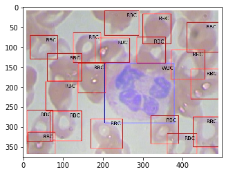

```python
image = plt.imread('imagesBox/BloodImage_00000.jpg')
plt.imshow(image)
```